# Tugas Praktikum Pertemuan 4

# Proses MA(2)

Proses MA dapat dituliskan sebagai berikut:

$$yt=c+et+θ_1e_{t−1}+θ_2e_{t−2}+⋯+θ_qe_{t−q}=c+e_t+∑θ_ie_{t−i}$$
Terlihat bahwa $e_t$ atau white noise berperan penting dalam pembangkitan proses MA.

## Membangkitkan Data

Berikut membangkitkan data MA(2) dengan $θ_1$=0.4 dan $θ_2$=0.6
$$Y_t
= e_t+0.4e_{t-1}+0.6e_{t-2}$$

### Dengan Manual

```r
set.seed(1081)
wn <- rnorm(300)
ma2 = wn[c(1,2)]
for(i in 3:300){
   ma2[i] <- wn[i] + 0.4 * wn[i - 1] +  0.6 * wn[i - 2]
}
head(ma2)
```

```
## [1] -0.33243340 -0.03708079  1.94730457  1.27042241  0.59396196 -0.04041334
```

### Dengan arima.sim

```r
set.seed(1081)
ma2. <- arima.sim(list(order=c(0,0,2), ma=c(0.4,0.6)), n=300)
head(ma2.)
```

```
## [1]  1.94730457  1.27042241  0.59396196 -0.04041334 -1.35199196 -0.09799070
```

## Karakteristik Plot MA(2)

### Plot Time Series

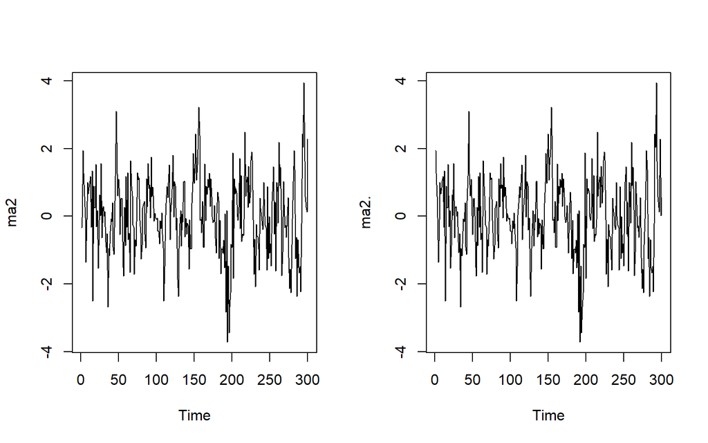

```r
par(mfrow = c(1, 2))
ts.plot(ma2)
ts.plot(ma2.)
```

Berdasarkan plot time series di atas, dapat dilihat bahwa data MA(2) yang dibangkitkan stasioner dalam rataan.

### Plot ACF

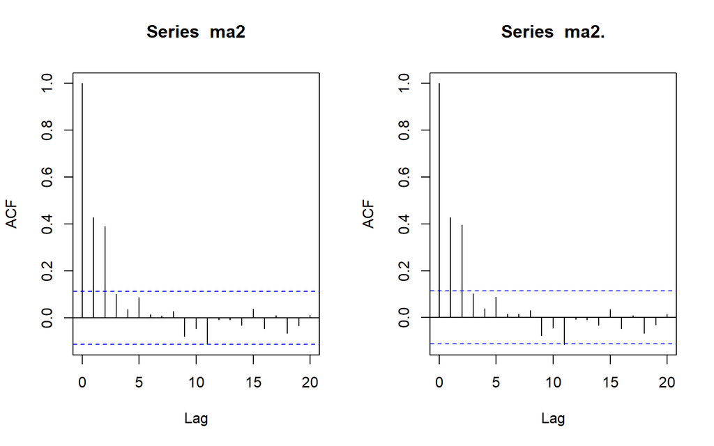

```r
par(mfrow = c(1, 2))
acf(ma2,lag.max = 20)
acf(ma2.,lag.max = 20)
```

Berdasarkan kedua plot AFC di atas, dapat dilihat bahwa plot ACF cuts off di lag kedua.

### Plot PACF

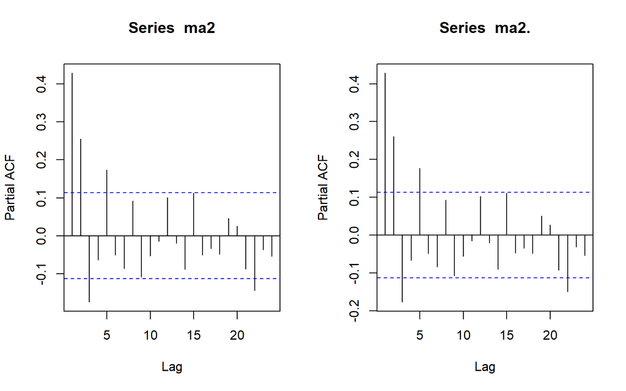

```r
par(mfrow = c(1, 2))
pacf(ma2)
pacf(ma2.)
```

Berdasarkan kedua plot PACF di atas, dapat dilihat bahwa plot PACF cenderung tails off dan membentuk gelombang sinus.

### Plot EACF

```r
TSA::eacf(ma2)
```

```
## AR/MA
##   0 1 2 3 4 5 6 7 8 9 10 11 12 13
## 0 x x o o o o o o o o o  o  o  o
## 1 x x o o o o o o o o x  o  o  o
## 2 x x o x o o o o o o x  o  o  o
## 3 x x o o o o o o o o o  o  o  o
## 4 x x x o o o o o o o o  o  o  o
## 5 x x x o o o o o o o o  o  o  o
## 6 x x o x x o o x o o o  o  o  o
## 7 x o x x x x o x o o o  o  o  o
```

```r
TSA::eacf(ma2.)
```

```
## AR/MA
##   0 1 2 3 4 5 6 7 8 9 10 11 12 13
## 0 x x o o o o o o o o o  o  o  o
## 1 x x o o o o o o o o o  o  o  o
## 2 x x o x o o o o o o x  o  o  o
## 3 x x o o o o o o o o o  o  o  o
## 4 x x x o o o o o o o o  o  o  o
## 5 x x x o o o o o o o o  o  o  o
## 6 x x o o o o o x o o o  o  o  o
## 7 x o x o x x o x o o o  o  o  o
```

Berdasarkan kedua pola segitiga nol pada plot EACF di atas, dapat dilihat bahwa segitiga nol berada pada ordo AR(0) dan ordo MA(2)

## Scatter Plot Antar Lag & Autokorelasi

### Korelasi antara $Y_t$ dengan $Y_{t−1}$

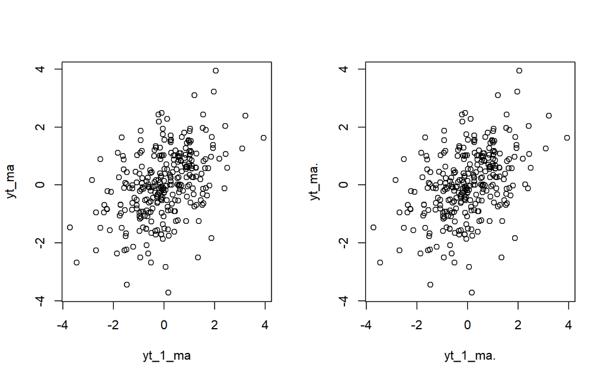

```r
#Yt
yt_ma <- ma2[-1]
yt_ma. <- ma2.[-1]

#Yt-1
yt_1_ma <- ma2[-300]
yt_1_ma. <- ma2.[-300]

par(mfrow = c(1, 2))
plot(y=yt_ma,x=yt_1_ma)
plot(y=yt_ma.,x=yt_1_ma.)
```

Berdasarkan scatterplot di atas, dapat dilihat bahwa terdapat hubungan positif antara $Y_t$ dengan $Y_{t−1}$. Hal ini sesuai dengan teori.

```r
cor(yt_ma,yt_1_ma)
```

```
## [1] 0.4309117
```

```r
cor(yt_ma.,yt_1_ma.)
```

```
## [1] 0.4303001
```

### Korelasi antara $Y_t$ dengan $Y_{t−2}$

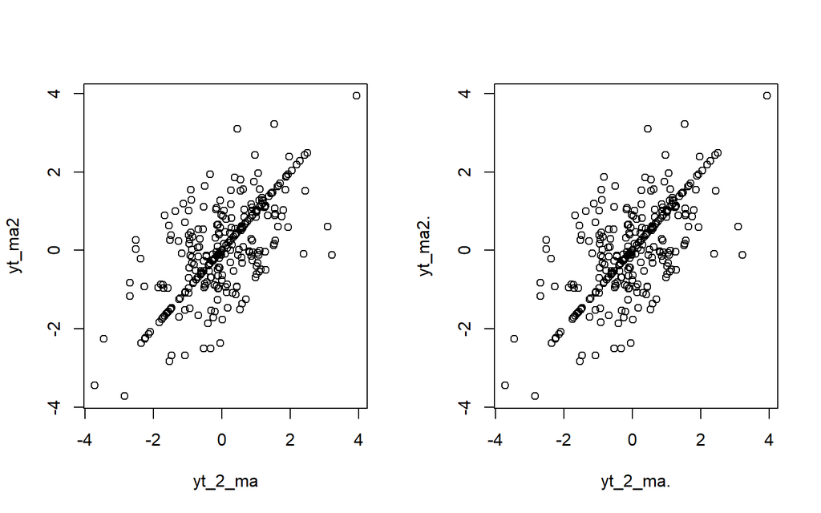

```r
#Yt
yt_ma2 <- ma2[-c(1,2)]
yt_ma2. <- ma2.[-c(1,2)]

#Yt-2
yt_2_ma <- ma2[-c(199,200)]
yt_2_ma. <- ma2.[-c(199,200)]

par(mfrow = c(1, 2))
plot(y=yt_ma2,x=yt_2_ma)
plot(y=yt_ma2.,x=yt_2_ma.)
```

Berdasarkan scatterplot di atas, dapat dilihat bahwa terdapat hubungan linier positif yang kuat antara $Y_t$ dengan $Y_{t−2}$

```r
cor(yt_ma2,yt_2_ma)
```

```
## [1] 0.6590278
```

```r
cor(yt_ma2.,yt_2_ma.)
```

```
## [1] 0.653205
```

### Korelasi antara $Y_t$ dengan $Y_{t−3}$

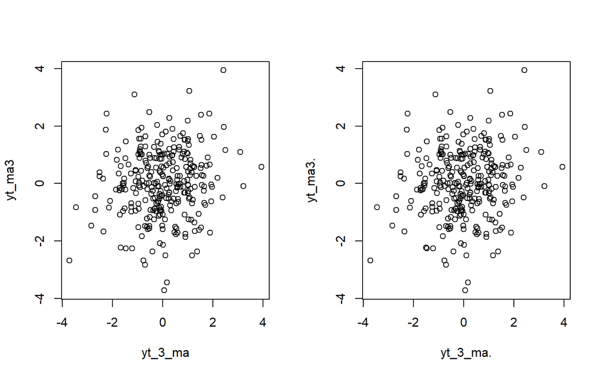

```r
#Yt
yt_ma3<- ma2[-c(1,2,3)]
yt_ma3.<- ma2.[-c(1,2,3)]

#Yt-3
yt_3_ma <- ma2[-c(288,299,300)]
yt_3_ma. <- ma2.[-c(288,299,300)]

par(mfrow=c(1,2))
plot(y=yt_ma3,x=yt_3_ma)
plot(y=yt_ma3.,x=yt_3_ma.)
```

Berdasarkan scatterplot tersebut, terlihat bahwa cenderung tidak terdapat hubungan antara $Y_t$ dengan $Y_{t−3}$

```r
par(mfrow=c(1,2))
cor(yt_ma3,yt_3_ma)
```

```
## [1] 0.1323393
```

```r
cor(yt_ma3.,yt_3_ma.)
```

```
## [1] 0.135203
```

Korelasi antara $Y_t$ dengan $Y_{t−3}$ hasil simulasi mendekati teori yang ada yaitu 0.

# Proses AR(2)

Proses AR dapat dituliskan sebagai berikut:

$$y_t=c+e_t+ϕ_1Y_{t−1}+ϕ_2Y_{t−2}+⋯+ϕ_qY_{t−q}=c+e_t+∑ϕ_iY_{t−i}$$
Terlihat bahwa Yt berperan penting dalam pembangkitan proses AR.

## Membangkitkan Data

### Dengan Manual

```r
set.seed(1081)
wn = rnorm(300)

n<-length(wn)
n
```

```
## [1] 300
```

```r
ar2 <- c(1:n)
for (i in 3:n) {ar2[i]<-wn[i]+0.5*ar2[i-1]+0.2*ar2[i-2]}
head(ar2)
```

```
## [1] 1.000000 2.000000 3.361597 2.508831 1.052526 1.080480
```

### Dengan arima.sim

```r
set.seed(1081)
ar2. <- arima.sim(list(order=c(2,0,0), ar=c(0.5,0.2)), n=300)
head(ar2.)
```

```
## [1] -0.18751704  0.97811016 -0.26224503  0.05753244  0.70201136  0.08380808
```

## Karakteristik Plot AR(2)

### Plot Time Series

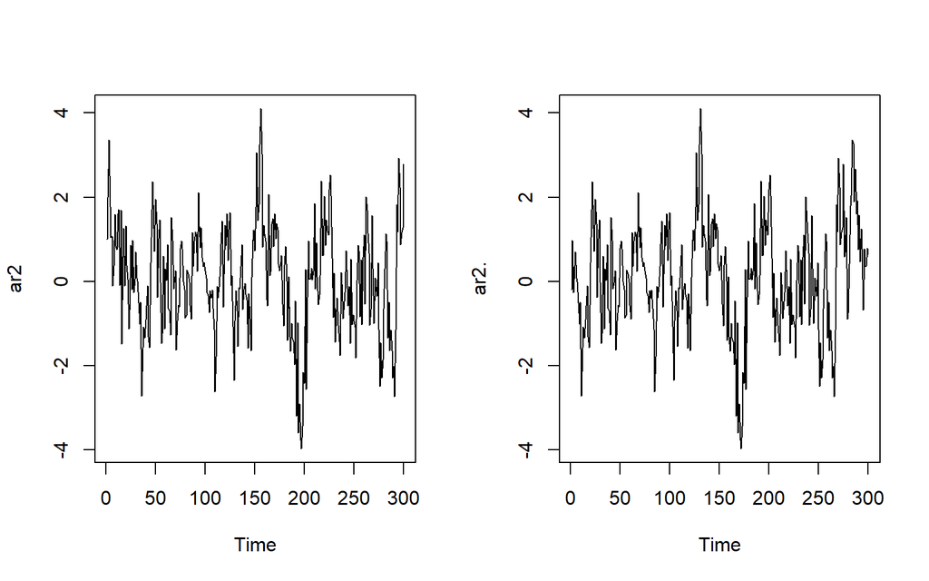

```r
par(mfrow=c(1,2))
ts.plot(ar2)
ts.plot(ar2.)
```

Berdasarkan plot time series di atas, dapat dilihat bahwa data AR(2) yang dibangkitkan stasioner dalam rataan.

### Plot ACF

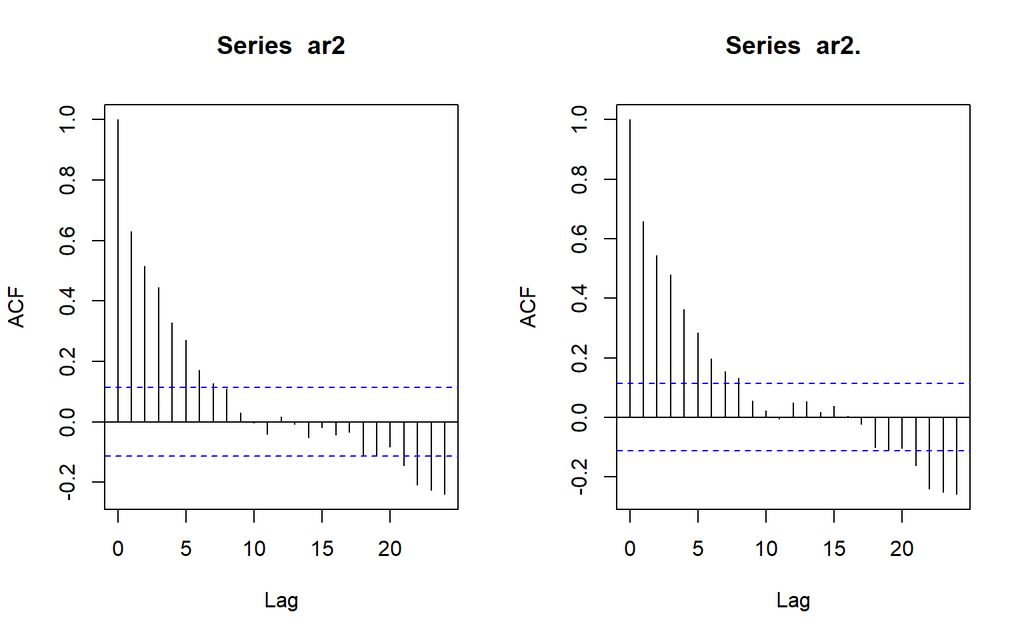

```r
par(mfrow=c(1,2))
acf(ar2)
acf(ar2.)
```

Berdasarkan plot ACF tersebut terlihat bahwa plot ACF cenderung tails off dan cenderung membentuk pola grafik sinus

### Plot PACF

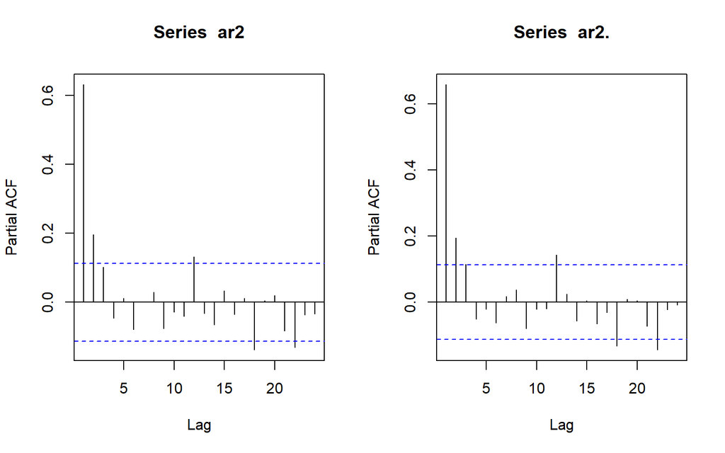

```r
par(mfrow=c(1,2))
pacf(ar2)
pacf(ar2.)
```

Berdasarkan plot PACF tersebut, terlihat bahwa plot PACF cuts off pada lag kedua, sejalan dengan teori.

### Plot EACF

```r
par(mfrow=c(1,2))
TSA::eacf(ar2)
```

```
## AR/MA
##   0 1 2 3 4 5 6 7 8 9 10 11 12 13
## 0 x x x x x x x o o o o  o  o  o
## 1 x o o o o o o o o o o  o  o  o
## 2 x x o o o o o o o o o  o  o  o
## 3 x o x o o o o x o o o  o  o  o
## 4 x o x o o o o o o o o  o  o  o
## 5 x x x x o o o o o o o  o  o  o
## 6 o x x x x o o o o o o  o  o  o
## 7 o o x x o o o o o o o  o  o  o
```

```r
TSA::eacf(ar2.)
```

```
## AR/MA
##   0 1 2 3 4 5 6 7 8 9 10 11 12 13
## 0 x x x x x x x x o o o  o  o  o
## 1 x o o o o o o o o o o  o  o  o
## 2 x x o o o o o o o o o  o  o  o
## 3 x x x o o o o o o o x  o  o  o
## 4 x x x o o o o o o o x  o  o  o
## 5 x x x x o o o o o o x  o  o  o
## 6 x x x o x x o o o o o  o  o  o
## 7 x x x o x x o o o o o  o  o  o
```

## Scatter Plot Antar Lag & Autokorelasi

### Korelasi antara $Y_t$ dengan $Y_{t−1}$

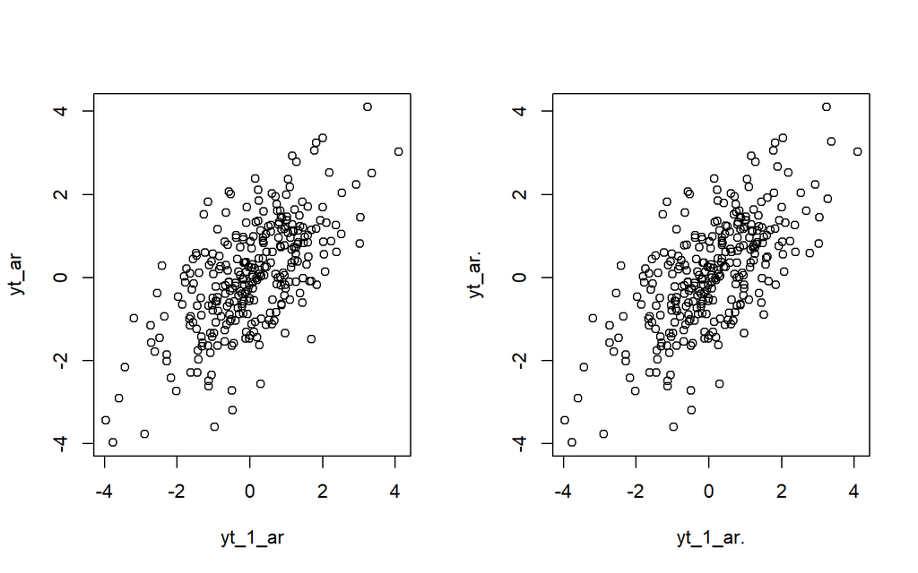

```r
#Yt
yt_ar <- ar2[-1]
yt_ar. <- ar2.[-1]

#Yt-1
yt_1_ar <- ar2[-300]
yt_1_ar. <- ar2.[-300]
par(mfrow=c(1,2))
plot(y=yt_ar,x=yt_1_ar)
plot(y=yt_ar.,x=yt_1_ar.)
```

Berdasarkan scatterplot tersebut, dapat dilihat bahwa terdapat hubungan positif antara $Y_t$ dengan $Y_{t−1}$. Hal ini sesuai dengan teori.

```r
cor(yt_ar,yt_1_ar)
```

```
## [1] 0.6357037
```

```r
cor(yt_ar.,yt_1_ar.)
```

```
## [1] 0.6590577
```

### Korelasi antara $Y_t$ dengan $Y_{t−2}$

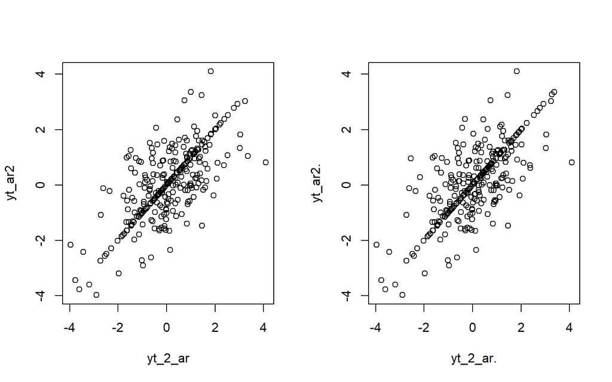

```r
#Yt
yt_ar2 <- ar2[-c(1,2)]
yt_ar2. <- ar2.[-c(1,2)]

#Yt-2
yt_2_ar <- ar2[-c(199,200)]
yt_2_ar. <- ar2.[-c(199,200)]
par(mfrow=c(1,2))
plot(y=yt_ar2,x=yt_2_ar)
plot(y=yt_ar2.,x=yt_2_ar.)
```

Berdasarkan scatterplot tersebut, dapat dilihat bahwa terdapat hubungan positif antara $Y_t$ dengan $Y_{t−2}$. Hal ini sesuai dengan teori.

```r
cor(yt_ar2,yt_2_ar)
```

```
## [1] 0.7113433
```

```r
cor(yt_ar2.,yt_2_ar.)
```

```
## [1] 0.722542
```

### Korelasi antara $Y_t$ dengan $Y_{t−3}$

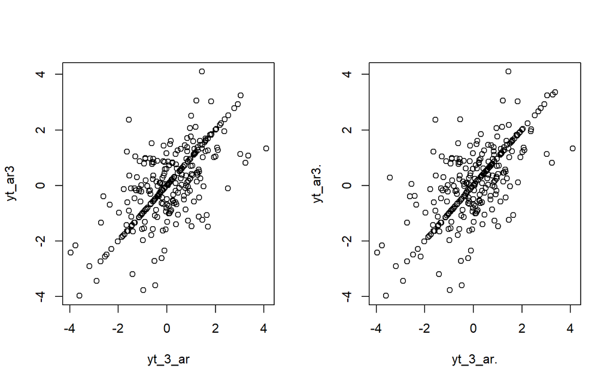

```r
#Yt
yt_ar3 <- ar2[-c(1,2,3)]
yt_ar3. <- ar2.[-c(1,2,3)]

#Yt-3
yt_3_ar <- ar2[-c(198,199,200)]
yt_3_ar. <- ar2.[-c(198,199,200)]
par(mfrow=c(1,2))
plot(y=yt_ar3,x=yt_3_ar)
plot(y=yt_ar3.,x=yt_3_ar.)
```

Berdasarkan scatterplot tersebut, dapat dilihat bahwa terdapat hubungan positif antara $Y_t$ dengan $Y_{t−3}$. Hal ini sesuai dengan teori

```r
cor(yt_ar3,yt_3_ar)
```

```
## [1] 0.6849887
```

```r
cor(yt_ar3.,yt_3_ar.)
```

```
## [1] 0.7010265
```

# Proses ARMA(2,2)

## Membangkitkan Data

### Dengan Manual

```r
set.seed(1081)
wn = rnorm(300)
n = length(wn)
phi1 = 0.5
phi2 = 0.2
theta1 = 0.4
theta2 = 0.6

arma22=c(1:n)
for (i in 3:n){arma22[i] = phi1*arma22[i-1] + phi2*arma22[i-2]  + theta1*wn[i-1] + theta2*wn[i-2] +wn[i]}
head(arma22)
```

```
## [1] 1.000000 2.000000 3.147305 3.244075 2.845460 2.031132
```

### Dengan arima.sim

```r
set.seed(1081)
arma22. <- arima.sim(list(order=c(2,0,2), ar = c(0.5,0.2), ma = c(0.4,0.6)), n=300)
head(arma22.)
```

```
## [1]  0.01676068  0.53970779  0.56783532  0.39925255  0.46018351 -0.44822081
```

## Karakteristik Plot ARMA(2,2)

### Plot Time Series

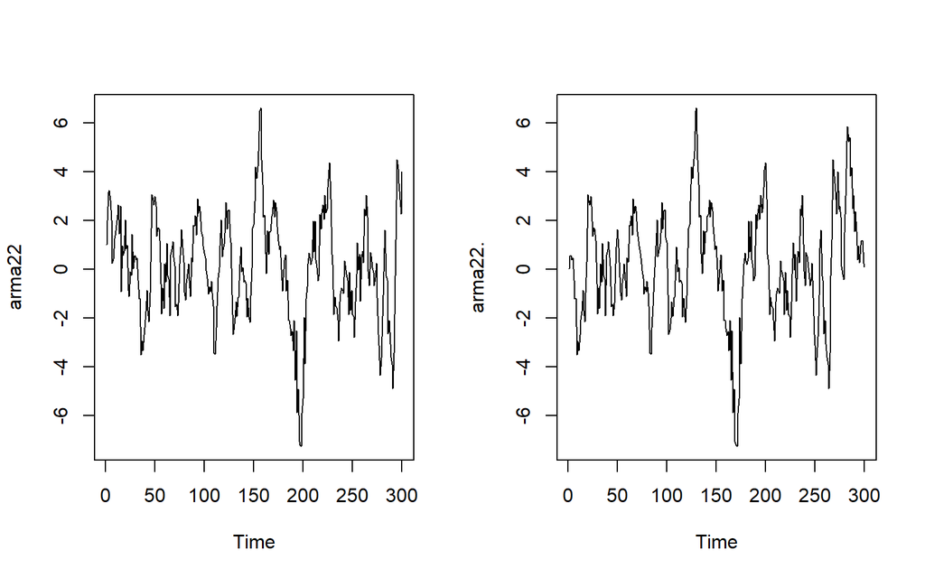

```r
par(mfrow = c(1, 2))
ts.plot(arma22)
ts.plot(arma22.)
```

Berdasarkan plot time series di atas, dapat dilihat bahwa data ARMA(2,2) yang dibangkitkan stasioner dalam rataan.

### Plot ACF

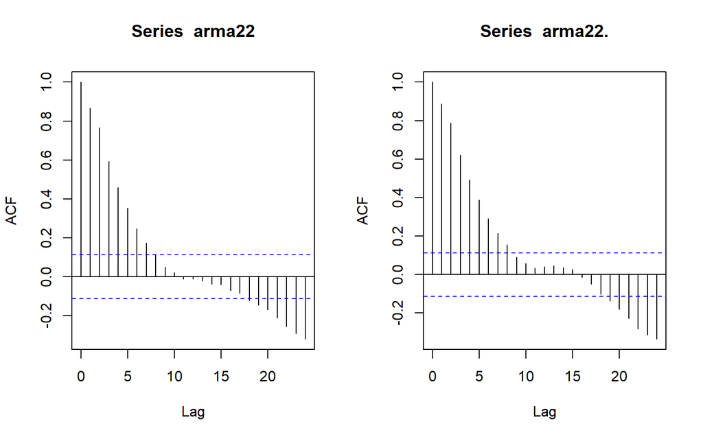

```r
par(mfrow = c(1, 2))
acf(arma22)
acf(arma22.)
```

Berdasarkan plot ACF tersebut, dapat dilihat bahwa model ARMA(2,2) hasil simulasi memiliki plot ACF yang tails off, sesuai dengan teori yang ada

### Plot PACF

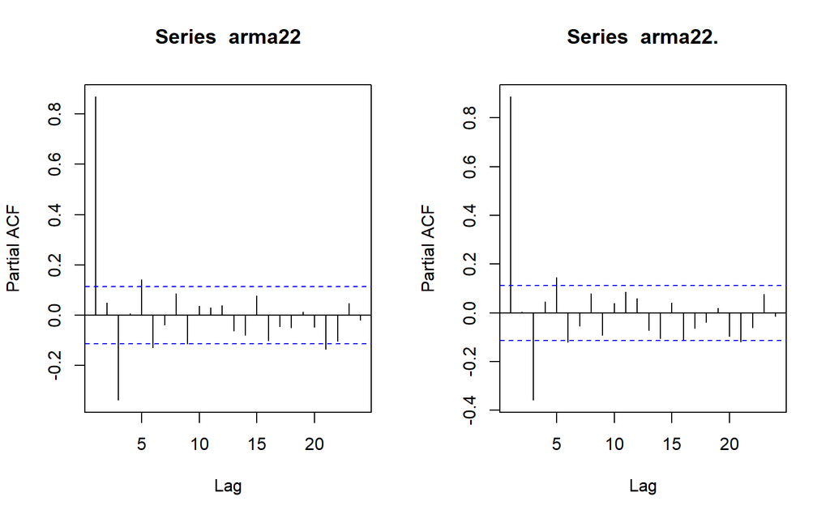

```r
par(mfrow = c(1, 2))
pacf(arma22)
pacf(arma22.)
```

Berdasarkan plot PACF tersebut, sapat dilihat bahwa model ARMA(2,2) hasil simulasi memiliki plot PACF yang tails off, sesuai dengan teori

### Plot EACF

```r
TSA::eacf(arma22)
```

```
## AR/MA
##   0 1 2 3 4 5 6 7 8 9 10 11 12 13
## 0 x x x x x x x o o o o  o  o  o
## 1 o x o o o o o o o o x  o  o  o
## 2 x x x o o o o o o o o  o  o  o
## 3 o x o o x o o x o o o  o  o  o
## 4 x x x x x o o x o o o  o  o  o
## 5 x x x o x x o x o o o  o  o  o
## 6 x x x x x o o x o o o  o  o  o
## 7 x o x x x x x x o o o  o  o  o
```

```r
TSA::eacf(arma22.)
```

```
## AR/MA
##   0 1 2 3 4 5 6 7 8 9 10 11 12 13
## 0 x x x x x x x x o o o  o  o  o
## 1 o x o o o o o o o o o  o  o  o
## 2 o x x o o o o o o o x  o  o  o
## 3 x x o o o o o o o o x  o  o  o
## 4 x x x o x o o o o o o  o  o  o
## 5 x x x o x o o o o o o  o  o  o
## 6 x x x x x o o o o o o  o  o  o
## 7 x o x x x o o x o o o  o  o  o
```

## Scatter Plot Antar Lag & Autokorelasi

### Korelasi antara $Y_t$ dengan $Y_{t−1}$

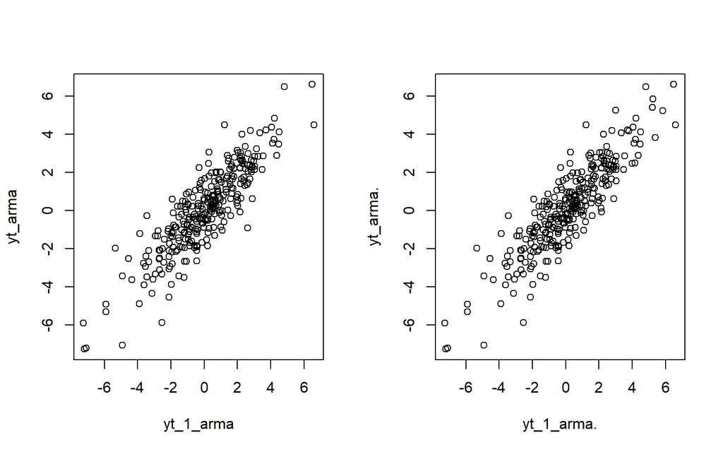

```r
#Yt
yt_arma <- arma22[-1]
yt_arma. <- arma22.[-1]

#Yt-1
yt_1_arma <- arma22[-300]
yt_1_arma. <- arma22.[-300]
par(mfrow=c(1,2))
plot(y=yt_arma,x=yt_1_arma)
plot(y=yt_arma.,x=yt_1_arma.)
```

Berdasarkan scatterplot tersebut, dapat dilihat bahwa terdapat hubungan positif antara $Y_t$ dengan $Y_{t−1}$. Hal ini sesuai dengan teori.

```r
cor(yt_arma,yt_1_arma)
```

```
## [1] 0.8730569
```

```r
cor(yt_arma.,yt_1_arma.)
```

```
## [1] 0.8863302
```

### Korelasi antara $Y_t$ dengan $Y_{t−2}$

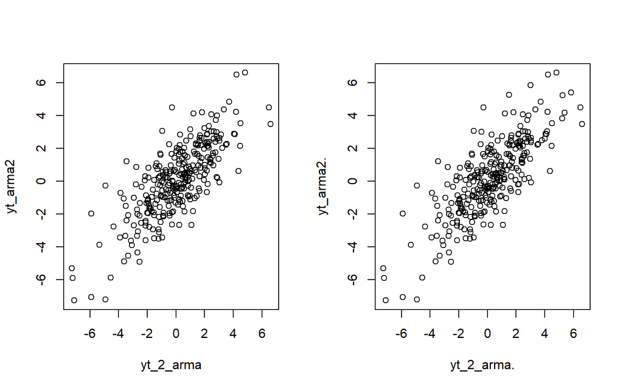

```r
#Yt
yt_arma2 <- arma22[-c(1,2)]
yt_arma2. <- arma22.[-c(1,2)]

#Yt-2
yt_2_arma <- arma22[-c(299,300)]
yt_2_arma. <- arma22.[-c(299,300)]
par(mfrow=c(1,2))
plot(y=yt_arma2,x=yt_2_arma)
plot(y=yt_arma2.,x=yt_2_arma.)
```

Berdasarkan scatterplot tersebut, dapat dilihat bahwa terdapat hubungan positif antara $Y_t$ dengan $Y_{t−2}$. Hal ini sesuai dengan teori.

```r
cor(yt_arma2,yt_2_arma)
```

```
## [1] 0.7724291
```

```r
cor(yt_arma2.,yt_2_arma.)
```

```
## [1] 0.7865022
```

### Korelasi antara $Y_t$ dengan $Y_{t−3}$

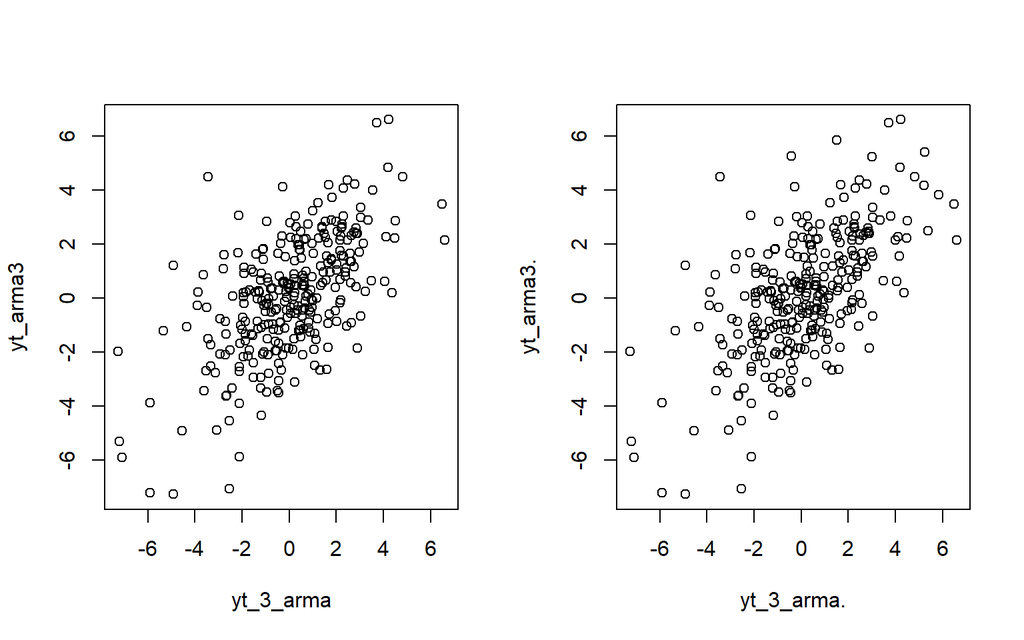

```r
#Yt
yt_arma3 <- arma22[-c(1,2,3)]
yt_arma3. <- arma22.[-c(1,2,3)]

#Yt-3
yt_3_arma <- arma22[-c(298,299,300)]
yt_3_arma. <- arma22.[-c(298,299,300)]
par(mfrow=c(1,2))
plot(y=yt_arma3,x=yt_3_arma)
plot(y=yt_arma3.,x=yt_3_arma.)
```

Berdasarkan scatterplot tersebut, dapat dilihat bahwa terdapat hubungan positif antara $Y_t$ dengan $Y_{t−3}$. Hal ini sesuai dengan teori.

```r
cor(yt_arma3,yt_3_arma)
```

```
## [1] 0.6006131
```

```r
cor(yt_arma3.,yt_3_arma.)
```

```
## [1] 0.6215086
```